# Structural Variant detection

INRAe-IFB-INSERM Bioinformatics School 2026

- Gabrièle Adam - INRAE

# Definition

Structural variations (SV) are genomic rearrangements with a size superior to 50pbs. They can change copy number, orientation and/or location of a sequence. They can be:

- Unbalanced (change DNA content):
  - Deletion
  - Duplication
  - Insertion
- Balanced (preserve DNA content):
  - Inversion
  - Translocation

# Different type of SVs

Figures from Alkan C, Coe BP, Eichler EE. Genome structural variation discovery and genotyping. Nat Rev Genet. 2011 May;12(5):363-76. doi: 10.1038/nrg2958

## **Deletion**: Loss of a segment of DNA

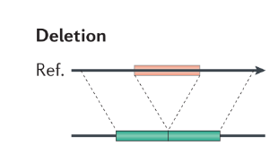

## **Duplication**: Additional copy of a segment

### **Tandem duplication**: the copy sit right next to the original

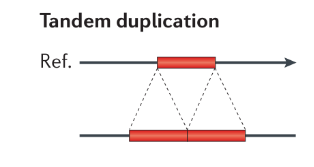

### **Interspeed duplication**: the copy is inserted elsewhere in the genome, on te same chromosome or not

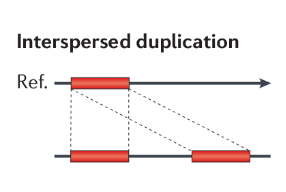

## **Insertion**

### **Novel insertion**: A new sequence that is not in the reference is added

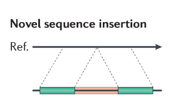

### **Mobile element insertion**: a transposable element has inserted a new copy

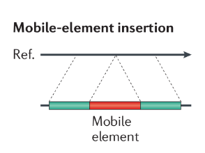

## **Inversion**: A segment is cut out, flipped 180°, and reinserted in place. No DNA is gained or lost

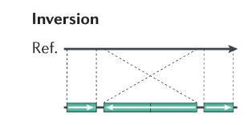

## **Translocation**: A segment moves to a different location, usually to another chromosome. We can talk about reciprocal translation when 2 chromosomes swap pieces.

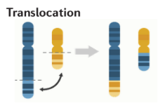

# How can we detect structural variation in an alignment?

All method infer SVs from how sequencing data deviate from the reference. These deviations show up in coverage, read-pair geometry, read alignment, or sequence and assembly comparison. No single method captures all SV classes, so methods differ mainly in which types and size ranges they can resolve.

## Read depth

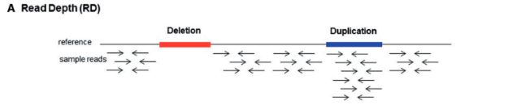

The coverage is proportional to the copy number. Best for DEL, DUP, CNV. Blind to balanced events (INV, reciprocal translocation) and to insertions. Breakpoints are only approximate (window resolution).

## Paired-Reads (discordant pairs)

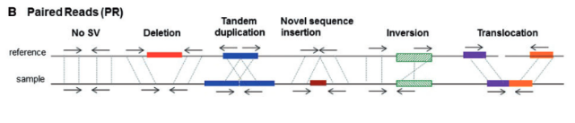

Paired reads should map with the expected orientation and insert size. Deviations reveal the SV type:

- larger insert = DEL
- smaller insert = INS
- same orientation of the reads = INV
- mates on different chromosomes = BND Breakpoints are only approximate. Insertions longer than the insert size are poorly sized. Unreliable when mates fall in repeats.

## Split reads

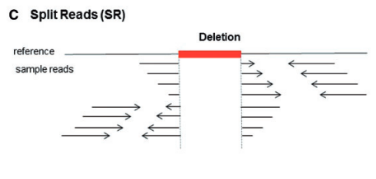

A single read spans a breakpoint, so its alignment is split (supplementary or soft-clipped, cf Mapping course). This gives base-pair resolution of the junction. Requires the read to cross the junction, which works poorly with short reads at repeat boundaries. Cannot easily resolve insertions longer than read length.

## De novo-assembly

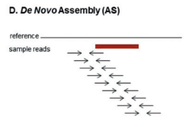

Reads around candidate breakpoints are reassembled to reconstruct the alternative allele sequence. De novo (ideally haplotype-resolved) assemblies are aligned to the reference or to each other, and rearrangements are called from synteny breaks.

# Short reads or long reads ?

**Short reads (Illumina)**: Depending on the tool and data quality

- low recall: 10–70% of SVs detected
- low precision: up to 90% false positives
- difficulty characterizing complex SVs (imprecise alignment in repetitive regions and low resolution)

Consensus calling with several detection tools can be useful with short-read data.

**Long reads (PacBio/MinION)**:

- better characterization of alterations in repetitive regions
- low coverage depth is sufficient (15–30x)

[figure not shown]

## Criteria

- Do I have long or short reads?
- How many samples do I have?
- What type of SVs I am looking for ?
- Is my depth of coverage enough?
- Which should be proiritize? Specificity or sensibility ?
- What is the output of the tool ?

## Tools for short reads

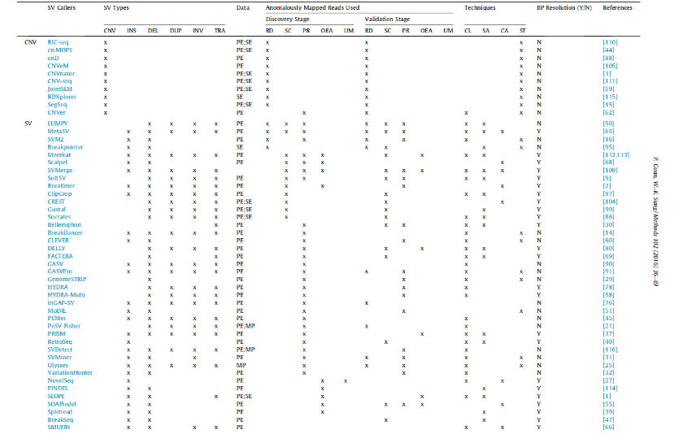

## Tools for long reads

| Tool | Read type | Variant type | Authors |
| --- | --- | --- | --- |
| DeepVariant | short/long | SNV/indel | Poplin et al. |
| NanoCaller | long | SNV/indel | Ahsan et al. |
| PEPPER | long | SNV/indel | Shafin et al. |
| cuteSV | long | SV/indel | Jiang et al. |
| Dysgu | short/long | SV/indel | Cleal et al. |
| pbsv | long | SV/indel | PacBio SMRT Link |
| Sniffles | long | SV/indel | Sedlazeck et al. |
| SVDSS | long | SV/indel | Denti et al. |
| SVIM | long | SV/indel | Heller and Vingron |
| DeepSV | long | SV/indel | Cai et al. |
| Hysa | short/long | SV/indel | Fan et al. |
| NanoSV | long | SV/indel | Euskirchen et al. |
| PBHoney | long | SV/indel | English et al. |

## What will the reads look like in long and short reads for the same type of SV?

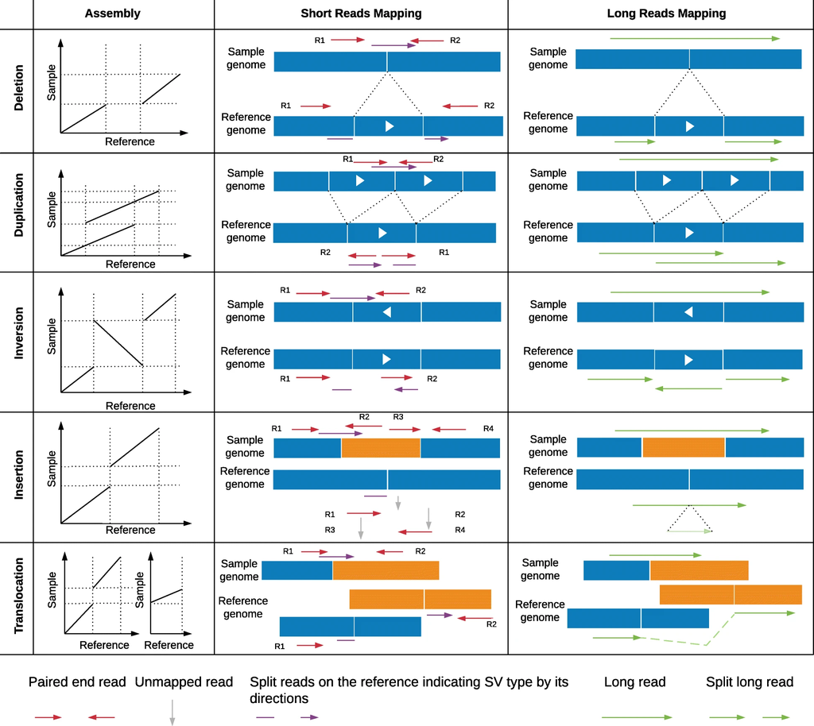

# Where are we in the workflow ?

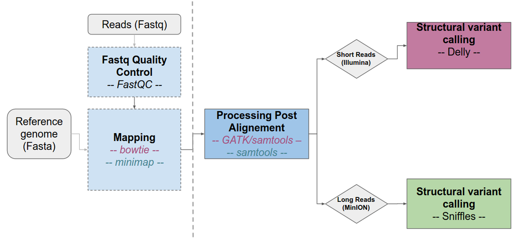

## Mapping

**Short Reads** bowtie2 --threads 4 --very-sensitive --no-unal -x genomeRef -1 R1.fq.gz -2 R2. fq.gz -S output.sam

**Long Reads** minimap2 -t 4 -ayYL --MD --eqx -x asm20 Ref.fa subreads > output.sam

- a output in sam format
- -Y use soft clipping for supplementary alignments
- -L write CIGAR with >65535 ops at the CG tag
- -MD output the MD tag
- --eqx write =/X CIGAR operator
- asm20Use this if the average divergence is around several percent.

# Practice

# Project:

**Zymoseptoria tritici**: an ascomycete fungus, a pathogen of bread wheat, causing a foliar disease (Septoria tritici blotch, STB).

- Main disease of wheat (up to 50% yield loss).
- Haploid; 40 Mb genome sequenced in 2011: 13 core chromosomes + 8 accessory chromosomes.
- Strain sequenced with two technologies: Illumina and MinION.

**Purpose**: Sequencing is used to analyse isolates, mock communities and field samples to determine the pathogen population composition related to azole resistance

# Data and Tools

**Data**: a *Zymoseptoria tritici* strain sequenced with both Illumina and MinION. → each read set was aligned to the reference genome with the dedicated tools → the data were subset to the first 500 kb of chr10

**Tools**:

- Delly (*Bioinformatics*, Volume 28, Issue 18, 15 September 2012, Pages i333–i339, https://doi.org/10.1093/bioinformatics/bts378)
- Sniffles (*Nature Methods*, volume 15, pages 461–468 (2018), https://www.nature.com/articles/s41592-018-0001-7) with NGMLR mapping

# Where are we and in which folder are we going to work ?

Where are we ?

```python
pwd
```

How are we going to the right folder ?

```python
cd pathway_to/atelier_variant/TP_structural_variants
```

# 1.SV detection from Illumina short-read data

First, we will use Delly (paper here: doi: 10.1093/bioinformatics/bts378, code there: https://github.com/dellytools/delly). We start by working on short-read data.

```python
module load delly/0.8.3
```

How do you find out which command to use to run Delly?

```python
delly | cat
```

And more specifically, how do you run Delly for variant calling?

```python
delly call | cat
```

## 1.1 Indexing

As seen in the previous lectures, we will start by indexing our alignment and our reference. Load samtools and index the reference and the alignment:

```python
module load samtools/1.13
```

```python
samtools faidx Zymoseptoria_tritici.fa
```

```python
samtools index mapping_illumina_chr10_500kb.bam
```

## 1.2 Variant calling

Now, let's use Delly for variant calling:

```python
delly call -g Zymoseptoria_tritici.fa  -o SV_calling_illumina.bcf  mapping_illumina_chr10_500kb.bam
```

To look at this result:

```python
head SV_calling_illumina.bcf
```

Here the format is not VCF but BCF, so it needs to be converted.

```python
# Convert to VCF
module load bcftools/1.10.2
bcftools view SV_calling_illumina.bcf > SV_calling_illumina.vcf
```

Now we can look at our variants

**Step 1**: look at the file header only:

```python
grep "^#" SV_calling_illumina.vcf
```

**Step 2**: look at the first 3 variants only:

```python
grep -v "^#" SV_calling_illumina.vcf | head -n3
```

## 1.3 Counting SVs

How many variants are in the file?

```python
# How many variants?
grep -v -c "^#" SV_calling_illumina.vcf
```

```python
# How many good-quality variants?
grep -v "^#" SV_calling_illumina.vcf | grep -v -c "LowQual"
```

```python
# How many variants are of good quality in each type (DEL,DUP, INS, BND, etc ...?
grep -v "^#" SV_calling_illumina.vcf | grep -v "LowQual" | grep -c "<DEL>"
```

## 1.3 Extracting deletion information in a separate file

Extract good-quality deletions:

```python
grep -v "^#" SV_calling_illumina.vcf | grep -v "LowQual" | grep "<DEL>"
```

```python
# Retrieve variant start positions
grep -v "^#" SV_calling_illumina.vcf | grep -v "LowQual" | grep "<DEL>" | \
cut -f1,2 > delly_del_start.txt
```

💡 **Sed Command**

`sed` (*stream editor*) reads a file line by line and **replaces text**, like "Find & Replace" in Word, but on the command line.

The syntax is always:

```
sed "s/WHAT_TO_FIND/WHAT_TO_PUT_INSTEAD/g"
```

| Part | Meaning |
| --- | --- |
| `s` | **s**ubstitute (replace) |
| `/` | separator between the parts |
| `g` | **g**lobal: replace *every* occurrence on the line, not only the first |

💡 **Tip: why the `\` at the end of the line?**

This command is long, so it is split over **two lines** to make it easier to read.

But for the terminal, pressing *Enter* means "run the command now". The backslash `\` at the end of a line tells the terminal: **"wait, the command is not finished, it continues on the next line"**.

So these two versions are exactly the same command:

```
grep -v "^#" file.vcf | grep "<DEL>" | cut -f8

grep -v "^#" file.vcf | grep "<DEL>" | \
cut -f8
```

⚠️ The `\` must be the **very last character** of the line: even an invisible space after it breaks the command.

```python
# Retrieve the other information
grep -v "^#" SV_calling_illumina.vcf | grep -v "LowQual" | grep "<DEL>" | \
cut -f8 | cut -d ";" -f1,4,5,13 | sed "s/;/\t/g" > delly_del_info.txt
```

Merge the 2 files and format:

```python
# Merge the two files
paste -d '\t' delly_del_start.txt delly_del_info.txt > delly_del.txt
```

```python
# Format and clean up
awk '{OFS="\t" ; print $1,$2,$4,$3,$5,$6}' delly_del.txt | sed "s/END=//g" > delly_del.tsv
```

💡 **Tip: what does `awk` do here?**

`awk` is a tool that reads a file **line by line** and sees each line as a **row of columns**, like a spreadsheet. Each column gets a name: `$1` is the 1st column, `$2` the 2nd, `$3` the 3rd, and so on.

Here we use it to **reorder the columns**, so that the start and end of each deletion sit next to each other.

**The command**, piece by piece:

| Piece | Meaning |
| --- | --- |
| `'{ ... }'` | the instructions to apply to **every line** |
| `OFS="\t"` | separate the output columns with a **tab** (*Output Field Separator*) |
| `print $1,$2,$4,$3,$5,$6` | write the columns **in this new order** (note that `$4` now comes before `$3`) |
| `delly_del.txt` | the file to read |

Clean up:

```python
rm delly_del_info.txt delly_del_start.txt delly_del.txt
```

# 2. SV detection from MinION long-read data

For long-read data, we will use another caller: **Sniffles** (paper here: https://www.nature.com/articles/s41592-018-0001-7, code there: https://github.com/fritzsedlazeck/Sniffles)

```python
module load sniffles/1.0.11
```

```python
sniffles --help
```

No reference genome needed!

## 2.1 Indexing the alignment

```python
samtools index mapping_minion_chr10_500kb.bam
```

## 2.2 Variant calling

```python
sniffles -l 100 -m mapping_minion_chr10_500kb.bam -v SV_calling_minion.vcf
```

```python
grep '^#' SV_calling_minion.vcf
```

## 2.3 Counting SVs

How many SVs are located on chr10?

```python
cat SV_calling_minion.vcf | grep ^chr_10 | wc -l
```

How many are deletions/duplications/translocations/invertions/...?

```python
cat SV_calling_minion.vcf | grep ^chr_10 | grep "DEL" | wc -l
```

## 2.4 Extracting deletion positions in a separate file

Extract the chromosome and start position of each deletion

```python
cat SV_calling_minion.vcf | grep ^chr_10 | grep "DEL" | cut -f -1,2 > sniffles_del_start.txt
```

```python
Extract the end position of each deletion
```

```python
cat SV_calling_minion.vcf | grep ^chr_10 | grep "DEL" | cut -d ";" -f 4 | cut -d "=" -f 2 > sniffles_del_stop.txt
```

Extract additional deletion information

```python
cat SV_calling_minion.vcf | grep ^chr_10 | grep "DEL" | cut -f 8 | cut -d ";" -f 1 > sniffles_del_infos.txt
```

Paste everything together

```python
paste sniffles_del_start.txt sniffles_del_stop.txt sniffles_del_infos.txt > sniffles_del.tsv
```

Now clean-up

```python
rm sniffles_del_start.txt sniffles_del_stop.txt sniffles_del_infos.txt
```

# 3.Compare Delly and Sniffles results

Here we will look at the Delly and Sniffles results

```python
cat delly_del.tsv
```

```python
cat sniffles_del.tsv
```

Are the deletions at the same positions?

Download locally BAM alignments et their index:

- Zymoseptoria_tritici.fa/fai
- mapping_illumina_chr10_500kb.bam/bam.bai
- mapping_minion_chr10_500kb.bam/bam.bai Load reference Open BAM at the same positions for both analysis

## deletion 90309-101040 (illumina), 91233-98159 (Minion)

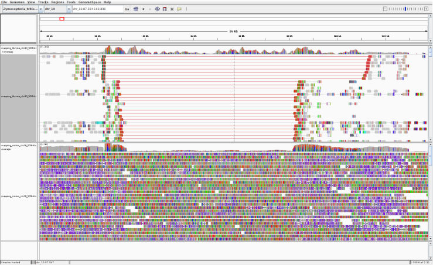

## deletion 57126-57598 (MinIon)

[figure not shown]

## deletion 111021-111676

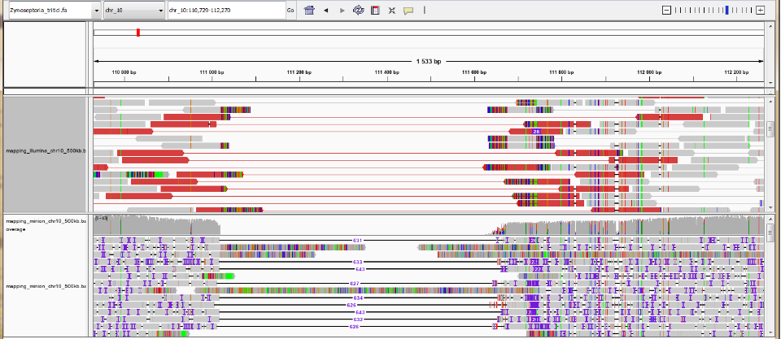

## deletion 191291-191343

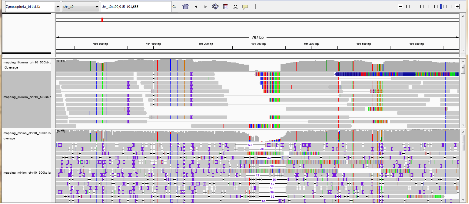

## deletion 343161-343273

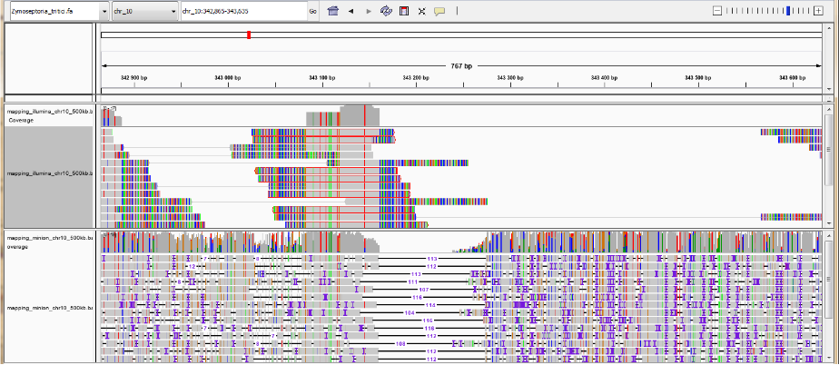

## Comparison between Sniffles and delly

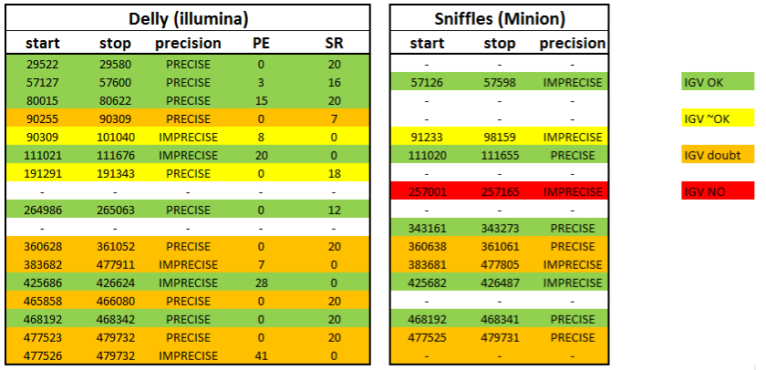

# Conclusion

SV detection lacks precision and produces both false positives and false negatives.

- Need to cross-check results across different tools and technologies
- Need to make proper use of each tool's quality metrics
- Need sufficient sequencing depth (especially for heterozygous variants)

Visually checking the results in IGV increases confidence in the detected SVs.